# Computer exercise 1: Survival analysis

**About this computer exercise.**

This exercise follows the lecture *Survival analysis* and the corresponding parts of Collett, *Modelling Survival Data in Medical Research* (4th ed.):

- **Chapter 1** — censoring, the survivor function $S(t)$, the hazard $h(t)$ and the cumulative hazard $H(t)$
- **Chapter 2** — Kaplan–Meier, Nelson–Aalen, median and percentiles, the log-rank test
- **Chapter 3** — Cox proportional hazards regression and hazard ratios
- **Section 4.4** — checking the proportional hazards assumption

Sections 1–6 each contain a short introduction, worked R code that you should run yourself, and questions to answer. The solutions are in a separate document, Computer exercise 1: solutions (`vignette("cs1-solutions")`), which uses the same numbering as this exercise.

The data are a synthetic Scottish metastatic breast cancer (MBC) cohort, `scottish_mbc_cohort`, which is distributed with this package. It is not one of the data sets from Collett (2023) — it comes from the teaching material of the Edinburgh Cancer Informatics Group, and the same cohort is used in their online tutorial, which is linked at the end of this document and cited under Data and software.

## Learning objectives

After this exercise you should be able to

- explain right-censoring and the independent (non-informative) censoring assumption;
- estimate and interpret $S(t)$ with Kaplan–Meier: survival at fixed times, median survival, and survival curves by group;
- estimate the cumulative hazard $H(t)$ with the Nelson–Aalen estimator and relate it to $S(t)$;
- test for differences in survival between groups with the log-rank test;
- fit and interpret a Cox proportional hazards model (hazard ratios with confidence intervals);
- check the proportional hazards assumption with a log–log plot and `cox.zph()`.

## Data and software

The analysis uses the `survival` package for the estimation, `ggsurvfit` for Kaplan–Meier plots and `gtsummary` for regression tables. Start by loading the packages and the data:

```r
# The package with the course data sets is attached last, because several of its
# data sets have the same names as data sets in `survival` (for example
# `myeloma` and `ovarian`); the most recently attached package is the one that
# is found first.
library(tidyverse)
library(survival)
library(ggsurvfit)
library(gtsummary)
library(sta310)

mbc <- scottish_mbc_cohort
glimpse(mbc)
```

```
#> Rows: 850
#> Columns: 21
#> $ patient_id           <chr> "MBC0001", "MBC0002", "MBC0003", "MBC0004", "MBC0…
#> $ health_board         <chr> "NHS Highland", "NHS Lothian", "NHS Tayside", "NH…
#> $ age_at_diagnosis     <dbl> 58, 80, 45, 72, 79, 87, 79, 74, 51, 74, 74, 42, 5…
#> $ sex                  <chr> "Female", "Female", "Female", "Female", "Female",…
#> $ simd_quintile        <dbl> 1, 4, 2, 4, 2, 1, 3, 1, 3, 4, 1, 1, 5, 1, 1, 4, 4…
#> $ ecog_ps              <dbl> 0, 1, 0, 2, 0, 0, 3, 3, 1, 0, 2, 1, 0, 1, 2, 1, 0…
#> $ er_status            <chr> "Negative", "Negative", "Negative", "Negative", "…
#> $ pr_status            <chr> "Negative", "Negative", "Negative", "Negative", "…
#> $ her2_status          <chr> "Negative", "Negative", "Negative", "Negative", "…
#> $ n_metastatic_sites   <dbl> 1, 1, 2, 1, 1, 2, 2, 3, 2, 1, 1, 4, 5, 2, 4, 4, 2…
#> $ bone_mets            <chr> "Yes", "No", "Yes", "No", "No", "Yes", "Yes", "Ye…
#> $ liver_mets           <chr> "Yes", "No", "No", "No", "No", "No", "No", "Yes",…
#> $ lung_mets            <chr> "No", "No", "No", "Yes", "Yes", "No", "No", "Yes"…
#> $ brain_mets           <chr> "No", "No", "No", "No", "No", "Yes", "No", "No", …
#> $ presentation         <chr> "De novo metastatic", "Recurrent", "Recurrent", "…
#> $ diagnosis_date       <date> 2020-03-01, 2022-11-11, 2021-07-25, 2022-05-21, …
#> $ first_line_treatment <chr> "Chemotherapy", "Chemotherapy", "Chemotherapy", "…
#> $ observed_time        <dbl> 40.8, 13.6, 9.2, 0.5, 4.8, 37.3, 13.7, 17.6, 11.1…
#> $ status               <int> 1, 0, 1, 1, 1, 1, 0, 1, 1, 1, 1, 1, 1, 0, 1, 1, 1…
#> $ age_group            <chr> "50-64", "75+", "<50", "65-74", "75+", "75+", "75…
#> $ hormone_receptor     <chr> "HR-negative", "HR-negative", "HR-negative", "HR-…
```

The cohort is entirely synthetic and contains no real patient data. It is documented, with its source and licence, on the help page `?scottish_mbc_cohort`.

The variables used in this exercise are:

| Variable | Description |
| --- | --- |
| `patient_id` | Patient identifier |
| `observed_time` | Follow-up time in months from diagnosis to death or censoring |
| `status` | Event indicator: 1 = death, 0 = censored (alive at last follow-up) |
| `age_at_diagnosis` | Age at diagnosis (years) |
| `ecog_ps` | ECOG performance status at baseline: 0 (best) to 3 (worst) |
| `hormone_receptor` | Hormone receptor status: `HR-positive` / `HR-negative` |
| `her2_status` | HER2 status: `Positive` / `Negative` |
| `n_metastatic_sites` | Number of metastatic sites at diagnosis |
| `presentation` | `De novo metastatic` or `Recurrent` |
| `first_line_treatment` | First-line treatment |

## 1. Time-to-event data and censoring

In survival analysis the outcome has two parts: **how long** each subject was followed (the survival time) and **what happened** at the end of that time (event or censoring). Right-censoring means that we only know that the true event time is *larger* than the observed time. All the methods in this exercise assume that censoring is **independent** (non-informative): a patient censored at time $t$ must be representative of all patients who were still event-free at $t$.

**1.** The data set has one row per patient. In your own words, answer:

1. What is the time origin (start of follow-up)?
2. What is the time scale, and in which unit is it measured?
3. What is the event of interest?
4. What does `status = 0` mean?
5. Name two reasons why a patient in this cohort could be censored.

**2.** Describe the cohort numerically: how many patients are there, how many deaths, how many censored observations, and what percentage is censored? What is the range of the follow-up times?

**3.** True or false? Justify each answer briefly.

1. A patient censored at 10 months is still in the risk set at 12 months.
2. If censoring is informative, the Kaplan–Meier estimate is always biased upwards.
3. The hazard $h(t)$ is the probability of dying at time $t$.
4. Survival times are usually right-skewed, so the mean survival time is preferred to the median.
5. Left-censoring means that the true event time is smaller than the observed time, and interval censoring means that the event time is known only to lie within an interval.

**4.** Explain why a logistic regression of `status` on the covariates is *not* the right model for these data. What extra information does a survival analysis use that logistic regression throws away?

## 2. The survivor function and the Kaplan–Meier estimator

The survivor function $S(t) = P(T \ge t)$ is the probability of surviving until time $t$ or longer. Without censoring it is estimated by the empirical proportion still event-free. With censoring we use the **Kaplan–Meier** (product-limit) estimator: at each event time $t_j$ we multiply by the conditional survival fraction $(n_j - d_j)/n_j$, where $n_j$ is the number at risk and $d_j$ the number of events at $t_j$,

$$\hat S(t) = \prod_{t_j \le t} \left(1 -
\frac{d_j}{n_j}\right).$$

The following code fits the overall survivor function and prints the estimate at a few time points:

```r
km_overall <- survfit(Surv(observed_time, status) ~ 1, data = mbc)
km_overall
```

```
#> Call: survfit(formula = Surv(observed_time, status) ~ 1, data = mbc)
#>
#>        n events median 0.95LCL 0.95UCL
#> [1,] 850    703   13.3    12.3    15.1
```

```r
summary(km_overall, times = c(6, 12, 24, 36, 48, 60), extend = TRUE)
```

```
#> Call: survfit(formula = Surv(observed_time, status) ~ 1, data = mbc)
#>
#>  time n.risk n.event survival std.err lower 95% CI upper 95% CI
#>     6    626     226   0.7341  0.0152       0.7050       0.7644
#>    12    463     163   0.5424  0.0171       0.5099       0.5769
#>    24    207     184   0.3031  0.0164       0.2725       0.3371
#>    36     94      76   0.1790  0.0147       0.1523       0.2104
#>    48     27      44   0.0824  0.0124       0.0614       0.1106
#>    60      9       8   0.0515  0.0117       0.0330       0.0804
```

and the figure below shows the same curve with a confidence band, a line at the median, and a number-at-risk table:

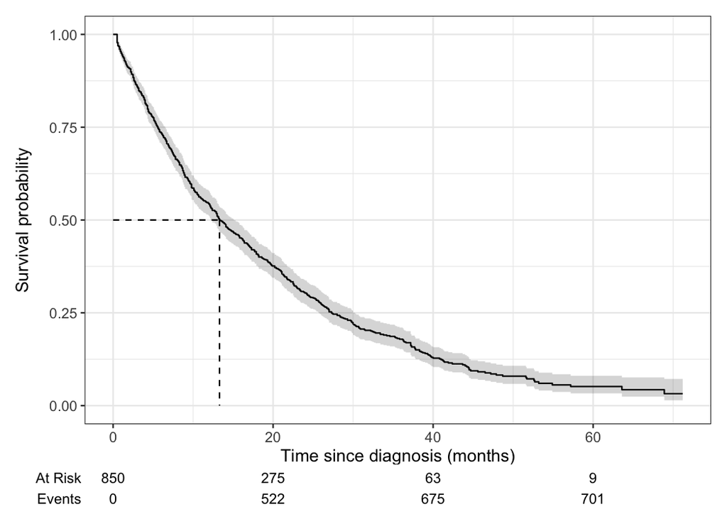

```r
survfit2(Surv(observed_time, status) ~ 1, data = mbc) |>
  ggsurvfit() +
  add_confidence_interval() +
  add_quantile(y_value = 0.5) +
  add_risktable() +
  labs(x = "Time since diagnosis (months)", y = "Survival probability")
```

**5.** Use the output above and report

1. the median survival time with a 95 % confidence interval;
2. $\hat S(12)$ and $\hat S(24)$ with 95 % confidence intervals.

Interpret each number in words.

**6.** Look at the `n.risk` column of the summary output.

1. How many patients are still at risk just before 6, 12 and 24 months?
2. Between two consecutive event times there may be only censored observations. Does the Kaplan–Meier estimate change there — does the curve drop or stay flat? Why?
3. The number at risk falls much faster than the number of deaths. Explain.

**7.** Describe the shape of the Kaplan–Meier curve in the figure. What does the long, almost flat part after about 60 months mean.

**8.** A colleague ignores censoring and estimates 2-year survival as “the proportion of patients who did not die within 24 months”, i.e. $1 - (\text{deaths within 24 months})/850$. Compute this naive estimate and compare it with the Kaplan–Meier estimate from Question 5. In which direction is the naive estimate biased, and why? Would the problem be worse or less serious in a study with more censoring?

**9.** Fit and plot the survivor function separately for the two hormone-receptor groups (`hormone_receptor`). Report the median survival time for each group and interpret the curves. Does the plot suggest that the two groups differ? *Hint:* reuse the code above with `Surv(observed_time, status) ~ hormone_receptor`.

## 3. Hazard and cumulative hazard

The hazard $h(t)$ is the instantaneous rate of the event at time $t$ among those still at risk. The cumulative hazard $H(t) = \int_0^t h(u)\,du$ accumulates the risk over time, and it is linked to the survivor function by $S(t) = \exp(-H(t))$, i.e. $H(t) = -\log S(t)$. The **Nelson–Aalen** estimator estimates $H(t)$ as the cumulative sum of the event fractions $\hat H(t) = \sum_{t_j \le t} d_j/n_j$.

The next two code blocks plot the cumulative hazard by hormone-receptor status and compare the Nelson–Aalen estimate with $-\log \hat S(t)$:

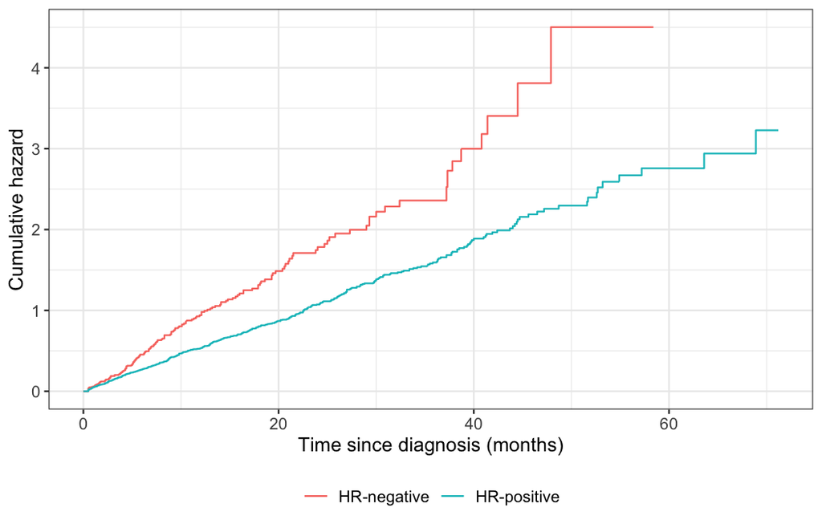

```r
km_hr <- survfit2(Surv(observed_time, status) ~ hormone_receptor, data = mbc)

km_hr |>
  ggsurvfit(type = "cumhaz") +
  labs(x = "Time since diagnosis (months)", y = "Cumulative hazard")
```

```r
tibble(
  time = km_overall$time,
  nelson_aalen = km_overall$cumhaz,
  neg_log_S = -log(km_overall$surv)
) |>
  filter(time %in% c(12, 24)) |>
  knitr::kable(digits = 3)
```

| time | nelson_aalen | neg_log_S |
| --- | --- | --- |
| 12 | 0.610 | 0.612 |
| 24 | 1.189 | 1.194 |

**10.** Interpret the cumulative hazard curves. Which group accumulates risk faster, and what does the *slope* of a cumulative hazard curve represent?

**11.** The `cumhaz` component of a `survfit` object is the Nelson–Aalen estimate of $H(t)$. The table above compares it with $-\log \hat S(t)$ (the Kaplan–Meier-based estimate of the cumulative hazard) at $t = 12$ and $t = 24$ months. They agree closely but not exactly — why?

## 4. The log-rank test

To compare two or more groups we test the null hypothesis that they have the same survival distribution. At every event time $t_j$ the **log-rank test** compares the observed number of deaths in a group, $o_{1j}$, with the number expected under the null hypothesis if the groups were exchangeable, $e_{1j} = d_j\, n_{1j}/n_j$, where $n_{1j}$ is the number at risk in group 1 and $n_j = n_{1j} + n_{2j}$. The total observed and expected counts are compared with a chi-squared test.

The code below compares the two hormone-receptor groups:

```r
lr_hr <- survdiff(Surv(observed_time, status) ~ hormone_receptor, data = mbc)
lr_hr
```

```
#> Call:
#> survdiff(formula = Surv(observed_time, status) ~ hormone_receptor,
#>     data = mbc)
#>
#>                                N Observed Expected (O-E)^2/E (O-E)^2/V
#> hormone_receptor=HR-negative 192      176      119     27.33      33.5
#> hormone_receptor=HR-positive 658      527      584      5.57      33.5
#>
#>  Chisq= 33.5  on 1 degrees of freedom, p= 7e-09
```

**12.** Use the output to report the observed and expected numbers of deaths in each group, the test statistic with degrees of freedom, and the p-value. State the conclusion in clinical language.

**13.** Survival is also related to ECOG performance status, which has four groups (0, 1, 2, 3). Carry out a log-rank test comparing the four groups (replace `hormone_receptor` by `ecog_ps`).

1. What is the null hypothesis here?
2. Report the test statistic, degrees of freedom and p-value.
3. A significant result tells you *that* the groups differ — what does it *not* tell you?

**Bonus (weighted tests).** The log-rank test gives equal weight to all event times. Suppose you suspected that the two hormone-receptor groups differed mainly *early* after diagnosis, with the curves converging later. Which alternative test would put more weight on early differences, and how would you run it in R? Does it change the conclusion for `hormone_receptor`?

**14.** The expected counts in `survdiff()` are built from the risk sets. Write a short loop that computes the observed and expected number of deaths for the **HR-negative** group directly, as
$$O = \sum_j o_{1j}, \qquad E = \sum_j
d_j\,\frac{n_{1j}}{n_j},$$
summed over all distinct event times. Compare with the `survdiff()` output from Question 12.

*Bonus:* also compute the variance

$$V = \sum_j \frac{d_j (n_j - d_j) n_{1j}
n_{2j}}{n_j^2 (n_j - 1)}$$

and the test statistic $(O - E)^2 / V$.

**15.** A colleague wants to compare the hormone-receptor groups while **adjusting for ECOG performance status**, but does not want to assume proportional hazards. Which test would you use? Carry it out (*hint:* add `+ strata(ecog_ps)` to the right-hand side of the `survdiff()` formula) and compare the result with the unadjusted log-rank test.

## 5. Cox proportional hazards regression

The Cox proportional hazards model writes the hazard for a patient with covariates $x_1, \dots, x_p$ as

$$h(t \mid x) = h_0(t)\exp(\beta_1 x_1 +
\beta_2 x_2 + \cdots + \beta_p x_p),$$

where $h_0(t)$ is an unspecified baseline hazard. The model is **semi-parametric**: the baseline hazard is left free, and the covariate effects are summarised by **hazard ratios**, $\mathrm{HR} = \exp(\beta)$, which are assumed to be constant over time.

The code below fits a univariable Cox model with `hormone_receptor` (the reference level is `HR-negative`):

```r
cox_hr <- coxph(Surv(observed_time, status) ~ hormone_receptor, data = mbc)
tbl_regression(cox_hr, exponentiate = TRUE)
```

| **Characteristic** | **HR** | **95% CI** | **p-value** |
| --- | --- | --- | --- |
| hormone_receptor |  |  |  |
| HR-negative | — | — |  |
| HR-positive | 0.60 | 0.51, 0.72 | <0.001 |

Abbreviations: CI = Confidence Interval, HR = Hazard Ratio

**16.** Use the table above.

1. Report the estimated hazard ratio with 95 % confidence interval and the p-value.
2. Interpret the hazard ratio in words (relative to the reference group).
3. Compute and interpret the hazard ratio for HR-negative *versus* HR-positive.
4. Compare the p-value with the log-rank p-value from Question 12.

**17.** Fit a multivariable Cox model with `hormone_receptor`, `her2_status`, `n_metastatic_sites`, `ecog_ps` (as a factor) and age per 10 years as covariates. Present the hazard ratios in a table and interpret each one. Which variables are associated with survival after adjustment?

*Hint:* create a modelling data set first, for example `mbc_model <- mbc |> mutate(ecog_ps = factor(ecog_ps), age_dec = age_at_diagnosis / 10)`, and use `tbl_regression(..., exponentiate = TRUE)`.

**18.** The rule of thumb for a Cox (or logistic) regression is that the number of covariates should be less than (number of events in the smaller group)/10. How many events are there in this cohort? How many covariates can you afford? Is the model in Question 17 reasonable from this point of view?

**Bonus (variable selection).** The lecture ends the Cox section with automatic variable selection (e.g. stepwise forward selection). What is the main statistical criticism of choosing the variables in a model by stepwise selection?

**19.** A colleague ignores the time-to-event nature of the data and fits a logistic regression of `status` on `hormone_receptor` instead (`glm(status ~ hormone_receptor, family = binomial)`).

1. Compute the odds ratio and compare it with the hazard ratio from Question 16.
2. Explain why the two measures differ.
3. Critique the following statement: *“Patients with HR-negative tumours were 2.5 times more likely to die.”*

## 6. Checking the proportional hazards assumption

The Cox model assumes that the hazard ratio between any two patients is **constant over time** (proportional hazards). Writing $S(t \mid x)$ for the survivor function, the model implies

$$\log\{-\log S(t \mid x)\} = \log\{-\log
S_0(t)\} + \beta x,$$

so the curves of $\log(-\log \hat S(t))$ against $t$ for two groups should be **parallel** if proportional hazards holds. The plot below shows this log–log (log-cumulative-hazard) plot for the two hormone-receptor groups:

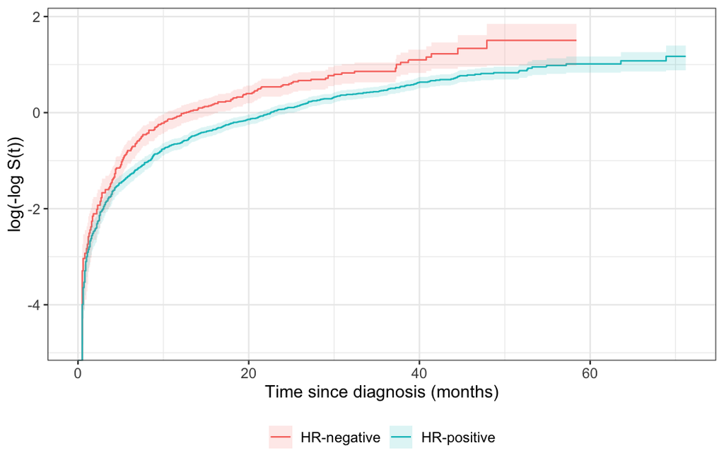

```r
survfit2(Surv(observed_time, status) ~ hormone_receptor, data = mbc) |>
  ggsurvfit(type = "cloglog") +
  add_confidence_interval(type = "ribbon", alpha = 0.15) +
  labs(x = "Time since diagnosis (months)", y = "log(-log S(t))")
```

**20.** Are the two curves in the log–log plot roughly parallel? What does that say about the proportional hazards assumption for `hormone_receptor`?

**21.** `cox.zph()` tests the proportional hazards assumption using (scaled) Schoenfeld residuals. Apply it to the multivariable model from Question 17.

1. Report and interpret the test for each covariate and for `GLOBAL`.
2. Is there anything to worry about? What would you do about it?

**22.** Suppose a covariate in a Cox model clearly violates the proportional hazards assumption. Describe **two** ways of handling this, and say what the resulting estimates mean.

## Wrap-up and reporting

When you report a survival analysis, check that you have

- stated the **time origin, time scale and event** definition;
- reported the **amount of censoring** and any concerns about informative censoring;
- given **number at risk** alongside every Kaplan–Meier plot;
- reported **medians and survival at fixed times with confidence intervals**, not the mean;
- paired the log-rank test with an **effect estimate** (hazard ratio) rather than only a p-value;
- checked and reported the **proportional hazards assumption** when using a Cox model;
- interpreted hazard ratios as **relative rates**, not as probabilities or relative risks.

## Further reading

- Collett, *Modelling Survival Data in Medical Research*, 4th ed.: Chapters 1–3 and Section 4.4.
- The course lecture *Survival analysis* (slides on censoring, Kaplan–Meier, the log-rank test and the Cox model).
- Edinburgh Cancer Informatics Group, [*Survival Analysis in R: A Practical Tutorial*](https://edinburgh-cancer-informatics.github.io/onco-stats/tutorials/survival_analysis_tutorial.html) — a longer walk-through of the same MBC cohort, with extra practice exercises. The cohort itself (and the simulation that generated it) is available in their [`onco-stats` repository](https://github.com/Edinburgh-Cancer-Informatics/onco-stats/tree/main/docs/data), and is redistributed here under its MIT licence; see `?scottish_mbc_cohort`.
- Thomas E. Love, [*Survival analysis*](https://thomaselove.github.io/432-notes/survival_data.html), Chapters 29–31.